# Optimal Treatment Analysis

## Outcome Variable

**Outcome Variable:** haz

## Predictor Variables

**Intervention Variable:** impfloor

**Adjustment Set:**

- arm
- sex
- W_mage
- meducyrs
- feducyrs
- hhwealth_quart
- hfoodsec
- W_mhtcm
- W_nrooms
- W_nchldlt5
- W_parity
- impsan
- safeh20
- delta_W_mage
- delta_meducyrs
- delta_feducyrs
- delta_hhwealth_quart
- delta_hfoodsec
- delta_W_mhtcm
- delta_W_nrooms
- delta_W_nchldlt5
- delta_W_parity
- delta_impsan
- delta_safeh20

## Stratifying Variables

The analysis was stratified on these variable(s):

- agecat
- studyid
- country

## Data Summary

| agecat | studyid | country | impfloor | n_cell | n |
| --- | --- | --- | --- | --- | --- |
| Birth | ki0047075b-MAL-ED | BANGLADESH | 1 | 216 | 234 |
| Birth | ki0047075b-MAL-ED | BANGLADESH | 0 | 18 | 234 |
| Birth | ki0047075b-MAL-ED | BRAZIL | 1 | 172 | 174 |
| Birth | ki0047075b-MAL-ED | BRAZIL | 0 | 2 | 174 |
| Birth | ki0047075b-MAL-ED | INDIA | 1 | 181 | 191 |
| Birth | ki0047075b-MAL-ED | INDIA | 0 | 10 | 191 |
| Birth | ki0047075b-MAL-ED | NEPAL | 1 | 66 | 164 |
| Birth | ki0047075b-MAL-ED | NEPAL | 0 | 98 | 164 |
| Birth | ki0047075b-MAL-ED | PERU | 1 | 56 | 259 |
| Birth | ki0047075b-MAL-ED | PERU | 0 | 203 | 259 |
| Birth | ki0047075b-MAL-ED | SOUTH AFRICA | 1 | 197 | 218 |
| Birth | ki0047075b-MAL-ED | SOUTH AFRICA | 0 | 21 | 218 |
| Birth | ki0047075b-MAL-ED | TANZANIA, UNITED REPUBLIC OF | 1 | 8 | 117 |
| Birth | ki0047075b-MAL-ED | TANZANIA, UNITED REPUBLIC OF | 0 | 109 | 117 |
| Birth | ki1000108-CMC-V-BCS-2002 | INDIA | 1 | 71 | 71 |
| Birth | ki1000108-CMC-V-BCS-2002 | INDIA | 0 | 0 | 71 |
| Birth | ki1000108-IRC | INDIA | 1 | 287 | 287 |
| Birth | ki1000108-IRC | INDIA | 0 | 0 | 287 |
| Birth | ki1017093-NIH-Birth | BANGLADESH | 1 | 24 | 28 |
| Birth | ki1017093-NIH-Birth | BANGLADESH | 0 | 4 | 28 |
| Birth | ki1017093c-NIH-Crypto | BANGLADESH | 1 | 21 | 27 |
| Birth | ki1017093c-NIH-Crypto | BANGLADESH | 0 | 6 | 27 |
| Birth | ki1114097-CONTENT | PERU | 1 | 2 | 2 |
| Birth | ki1114097-CONTENT | PERU | 0 | 0 | 2 |
| Birth | kiGH5241-JiVitA-3 | BANGLADESH | 1 | 1076 | 19563 |
| Birth | kiGH5241-JiVitA-3 | BANGLADESH | 0 | 18487 | 19563 |
| Birth | kiGH5241-JiVitA-4 | BANGLADESH | 1 | 71 | 822 |
| Birth | kiGH5241-JiVitA-4 | BANGLADESH | 0 | 751 | 822 |
| 6 months | ki0047075b-MAL-ED | BANGLADESH | 1 | 221 | 240 |
| 6 months | ki0047075b-MAL-ED | BANGLADESH | 0 | 19 | 240 |

[output cut: 62 more lines]

The following strata were considered:

- agecat: 24 months, studyid: ki0047075b-MAL-ED, country: BANGLADESH
- agecat: 24 months, studyid: ki0047075b-MAL-ED, country: BRAZIL
- agecat: 24 months, studyid: ki0047075b-MAL-ED, country: INDIA
- agecat: 24 months, studyid: ki0047075b-MAL-ED, country: NEPAL
- agecat: 24 months, studyid: ki0047075b-MAL-ED, country: PERU
- agecat: 24 months, studyid: ki0047075b-MAL-ED, country: SOUTH AFRICA
- agecat: 24 months, studyid: ki0047075b-MAL-ED, country: TANZANIA, UNITED REPUBLIC OF
- agecat: 24 months, studyid: ki1000108-CMC-V-BCS-2002, country: INDIA
- agecat: 24 months, studyid: ki1000108-IRC, country: INDIA
- agecat: 24 months, studyid: ki1017093-NIH-Birth, country: BANGLADESH
- agecat: 24 months, studyid: ki1017093b-PROVIDE, country: BANGLADESH
- agecat: 24 months, studyid: ki1017093c-NIH-Crypto, country: BANGLADESH
- agecat: 24 months, studyid: ki1113344-GMS-Nepal, country: NEPAL
- agecat: 24 months, studyid: ki1114097-CONTENT, country: PERU
- agecat: 24 months, studyid: kiGH5241-JiVitA-3, country: BANGLADESH
- agecat: 24 months, studyid: kiGH5241-JiVitA-4, country: BANGLADESH
- agecat: 6 months, studyid: ki0047075b-MAL-ED, country: BANGLADESH
- agecat: 6 months, studyid: ki0047075b-MAL-ED, country: BRAZIL
- agecat: 6 months, studyid: ki0047075b-MAL-ED, country: INDIA
- agecat: 6 months, studyid: ki0047075b-MAL-ED, country: NEPAL
- agecat: 6 months, studyid: ki0047075b-MAL-ED, country: PERU
- agecat: 6 months, studyid: ki0047075b-MAL-ED, country: SOUTH AFRICA
- agecat: 6 months, studyid: ki0047075b-MAL-ED, country: TANZANIA, UNITED REPUBLIC OF
- agecat: 6 months, studyid: ki1000108-CMC-V-BCS-2002, country: INDIA
- agecat: 6 months, studyid: ki1000108-IRC, country: INDIA
- agecat: 6 months, studyid: ki1017093-NIH-Birth, country: BANGLADESH
- agecat: 6 months, studyid: ki1017093b-PROVIDE, country: BANGLADESH
- agecat: 6 months, studyid: ki1017093c-NIH-Crypto, country: BANGLADESH
- agecat: 6 months, studyid: ki1113344-GMS-Nepal, country: NEPAL
- agecat: 6 months, studyid: ki1114097-CONTENT, country: PERU
- agecat: 6 months, studyid: kiGH5241-JiVitA-3, country: BANGLADESH
- agecat: 6 months, studyid: kiGH5241-JiVitA-4, country: BANGLADESH
- agecat: Birth, studyid: ki0047075b-MAL-ED, country: BANGLADESH
- agecat: Birth, studyid: ki0047075b-MAL-ED, country: BRAZIL
- agecat: Birth, studyid: ki0047075b-MAL-ED, country: INDIA
- agecat: Birth, studyid: ki0047075b-MAL-ED, country: NEPAL
- agecat: Birth, studyid: ki0047075b-MAL-ED, country: PERU
- agecat: Birth, studyid: ki0047075b-MAL-ED, country: SOUTH AFRICA
- agecat: Birth, studyid: ki0047075b-MAL-ED, country: TANZANIA, UNITED REPUBLIC OF
- agecat: Birth, studyid: ki1000108-CMC-V-BCS-2002, country: INDIA
- agecat: Birth, studyid: ki1000108-IRC, country: INDIA
- agecat: Birth, studyid: ki1017093-NIH-Birth, country: BANGLADESH
- agecat: Birth, studyid: ki1017093c-NIH-Crypto, country: BANGLADESH
- agecat: Birth, studyid: ki1114097-CONTENT, country: PERU
- agecat: Birth, studyid: kiGH5241-JiVitA-3, country: BANGLADESH
- agecat: Birth, studyid: kiGH5241-JiVitA-4, country: BANGLADESH

### Dropped Strata

- agecat: Birth, studyid: ki0047075b-MAL-ED, country: BRAZIL
- agecat: Birth, studyid: ki1000108-CMC-V-BCS-2002, country: INDIA
- agecat: Birth, studyid: ki1000108-IRC, country: INDIA
- agecat: Birth, studyid: ki1017093-NIH-Birth, country: BANGLADESH
- agecat: Birth, studyid: ki1114097-CONTENT, country: PERU
- agecat: 6 months, studyid: ki0047075b-MAL-ED, country: BRAZIL
- agecat: 6 months, studyid: ki1000108-CMC-V-BCS-2002, country: INDIA
- agecat: 6 months, studyid: ki1000108-IRC, country: INDIA
- agecat: 24 months, studyid: ki0047075b-MAL-ED, country: BRAZIL
- agecat: 24 months, studyid: ki1000108-CMC-V-BCS-2002, country: INDIA
- agecat: 24 months, studyid: ki1000108-IRC, country: INDIA

## Methods Detail

We’re interested in the causal parameters $E[Y_a]$ for all values of $a \in \mathcal{A}$. These parameters represent the mean outcome if, possibly contrary to fact, we intervened to set all units to have $A=a$. Under the randomization and positivity assumptions, these are identified by the statistical parameters $\psi_a=E_W[E_{Y|A,W}(Y|A=a,W)]$. In addition, we’re interested in the mean of $Y$, $E[Y]$ under no intervention (the observed mean). We will estimate these parameters by using SuperLearner to fit the relevant likelihood factors – $E_{Y|A,W}(Y|A=a,W)$ and $p(A=a|W)$, and then updating our likelihood fit using a joint TMLE.

For unadjusted analyses ($W=\{\}$), initial likelihoods were estimated using Lrnr_glm to estimate the simple $E(Y|A)$ and Lrnr_mean to estimate $p(A)$. For adjusted analyses, a small library containing Lrnr_glmnet, Lrnr_xgboost, and Lrnr_mean was used.

Having estimated these parameters, we will then use the delta method to estimate relative risks and attributable risks relative to a prespecified baseline level of $A$.

# Results Detail

## Results Plots

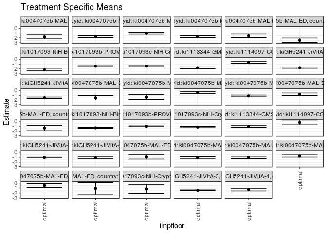

## Results Table

### Parameter: TSM

| agecat | studyid | country | intervention_level | baseline_level | estimate | ci_lower | ci_upper |
| --- | --- | --- | --- | --- | --- | --- | --- |
| Birth | ki0047075b-MAL-ED | BANGLADESH | optimal | observed | -0.9569576 | -1.3821746 | -0.5317405 |
| Birth | ki0047075b-MAL-ED | INDIA | optimal | observed | -1.0741682 | -1.2385159 | -0.9098205 |
| Birth | ki0047075b-MAL-ED | NEPAL | optimal | observed | -1.0404405 | -1.2689074 | -0.8119737 |
| Birth | ki0047075b-MAL-ED | PERU | optimal | observed | -0.7755528 | -0.9898428 | -0.5612629 |
| Birth | ki0047075b-MAL-ED | SOUTH AFRICA | optimal | observed | -0.5037064 | -0.9003040 | -0.1071087 |
| Birth | ki0047075b-MAL-ED | TANZANIA, UNITED REPUBLIC OF | optimal | observed | -1.0772508 | -2.3575614 | 0.2030598 |
| Birth | ki1017093c-NIH-Crypto | BANGLADESH | optimal | observed | -1.1875563 | -2.1051750 | -0.2699376 |
| Birth | kiGH5241-JiVitA-3 | BANGLADESH | optimal | observed | -1.4506767 | -1.5188991 | -1.3824543 |
| Birth | kiGH5241-JiVitA-4 | BANGLADESH | optimal | observed | -1.3264712 | -1.5941768 | -1.0587656 |
| 6 months | ki0047075b-MAL-ED | BANGLADESH | optimal | observed | -1.5422683 | -2.0185873 | -1.0659492 |
| 6 months | ki0047075b-MAL-ED | INDIA | optimal | observed | -1.3751450 | -1.8648117 | -0.8854783 |
| 6 months | ki0047075b-MAL-ED | NEPAL | optimal | observed | -0.4660366 | -0.6361815 | -0.2958917 |
| 6 months | ki0047075b-MAL-ED | PERU | optimal | observed | -1.1420991 | -1.3205194 | -0.9636788 |
| 6 months | ki0047075b-MAL-ED | SOUTH AFRICA | optimal | observed | -0.8149445 | -1.0753730 | -0.5545160 |
| 6 months | ki0047075b-MAL-ED | TANZANIA, UNITED REPUBLIC OF | optimal | observed | -1.4261344 | -1.9475179 | -0.9047509 |
| 6 months | ki1017093-NIH-Birth | BANGLADESH | optimal | observed | -1.3711823 | -1.4731056 | -1.2692589 |
| 6 months | ki1017093b-PROVIDE | BANGLADESH | optimal | observed | -1.0413917 | -1.1181904 | -0.9645930 |
| 6 months | ki1017093c-NIH-Crypto | BANGLADESH | optimal | observed | -1.2083044 | -1.3324200 | -1.0841889 |
| 6 months | ki1113344-GMS-Nepal | NEPAL | optimal | observed | -1.1047137 | -1.2939855 | -0.9154418 |
| 6 months | ki1114097-CONTENT | PERU | optimal | observed | -0.2653675 | -0.7512606 | 0.2205255 |
| 6 months | kiGH5241-JiVitA-3 | BANGLADESH | optimal | observed | -1.0663595 | -1.1377182 | -0.9950007 |
| 6 months | kiGH5241-JiVitA-4 | BANGLADESH | optimal | observed | -1.0934659 | -1.2492361 | -0.9376957 |
| 24 months | ki0047075b-MAL-ED | BANGLADESH | optimal | observed | -1.7780058 | -2.1745968 | -1.3814148 |
| 24 months | ki0047075b-MAL-ED | INDIA | optimal | observed | -1.7270831 | -1.9370882 | -1.5170779 |
| 24 months | ki0047075b-MAL-ED | NEPAL | optimal | observed | -1.0468282 | -1.2359056 | -0.8577507 |
| 24 months | ki0047075b-MAL-ED | PERU | optimal | observed | -1.7323639 | -1.9423380 | -1.5223898 |
| 24 months | ki0047075b-MAL-ED | SOUTH AFRICA | optimal | observed | -1.5614193 | -1.9016550 | -1.2211837 |
| 24 months | ki0047075b-MAL-ED | TANZANIA, UNITED REPUBLIC OF | optimal | observed | -2.4705930 | -2.9243803 | -2.0168058 |
| 24 months | ki1017093-NIH-Birth | BANGLADESH | optimal | observed | -2.1567024 | -2.2942528 | -2.0191519 |
| 24 months | ki1017093b-PROVIDE | BANGLADESH | optimal | observed | -1.4283349 | -1.5253150 | -1.3313547 |
| 24 months | ki1017093c-NIH-Crypto | BANGLADESH | optimal | observed | -1.4177296 | -1.5203382 | -1.3151211 |
| 24 months | ki1113344-GMS-Nepal | NEPAL | optimal | observed | -1.7491888 | -1.9417125 | -1.5566651 |
| 24 months | ki1114097-CONTENT | PERU | optimal | observed | -0.6691409 | -0.8466607 | -0.4916211 |
| 24 months | kiGH5241-JiVitA-3 | BANGLADESH | optimal | observed | -1.7366665 | -1.8483589 | -1.6249741 |
| 24 months | kiGH5241-JiVitA-4 | BANGLADESH | optimal | observed | -1.5114259 | -1.6645771 | -1.3582747 |

### Parameter: E(Y)

| agecat | studyid | country | intervention_level | baseline_level | estimate | ci_lower | ci_upper |
| --- | --- | --- | --- | --- | --- | --- | --- |
| Birth | ki0047075b-MAL-ED | BANGLADESH | observed | observed | -1.0229487 | -1.1509575 | -0.8949400 |
| Birth | ki0047075b-MAL-ED | INDIA | observed | observed | -1.0069634 | -1.1525107 | -0.8614160 |
| Birth | ki0047075b-MAL-ED | NEPAL | observed | observed | -0.6988415 | -0.8600838 | -0.5375991 |
| Birth | ki0047075b-MAL-ED | PERU | observed | observed | -0.9447876 | -1.0604945 | -0.8290808 |
| Birth | ki0047075b-MAL-ED | SOUTH AFRICA | observed | observed | -0.6917890 | -0.8248091 | -0.5587689 |
| Birth | ki0047075b-MAL-ED | TANZANIA, UNITED REPUBLIC OF | observed | observed | -0.8777778 | -1.0853531 | -0.6702024 |
| Birth | ki1017093c-NIH-Crypto | BANGLADESH | observed | observed | -1.1100000 | -1.5086894 | -0.7113106 |
| Birth | kiGH5241-JiVitA-3 | BANGLADESH | observed | observed | -1.5749762 | -1.5947643 | -1.5551882 |
| Birth | kiGH5241-JiVitA-4 | BANGLADESH | observed | observed | -1.4976642 | -1.5817349 | -1.4135935 |
| 6 months | ki0047075b-MAL-ED | BANGLADESH | observed | observed | -1.2033681 | -1.3212429 | -1.0854932 |
| 6 months | ki0047075b-MAL-ED | INDIA | observed | observed | -1.2159433 | -1.3345235 | -1.0973630 |
| 6 months | ki0047075b-MAL-ED | NEPAL | observed | observed | -0.5534934 | -0.6683107 | -0.4386762 |
| 6 months | ki0047075b-MAL-ED | PERU | observed | observed | -1.3280247 | -1.4371552 | -1.2188942 |
| 6 months | ki0047075b-MAL-ED | SOUTH AFRICA | observed | observed | -1.0548494 | -1.1845497 | -0.9251491 |
| 6 months | ki0047075b-MAL-ED | TANZANIA, UNITED REPUBLIC OF | observed | observed | -1.3613469 | -1.4843950 | -1.2382988 |
| 6 months | ki1017093-NIH-Birth | BANGLADESH | observed | observed | -1.4060639 | -1.4948910 | -1.3172368 |
| 6 months | ki1017093b-PROVIDE | BANGLADESH | observed | observed | -1.0871041 | -1.1635539 | -1.0106543 |
| 6 months | ki1017093c-NIH-Crypto | BANGLADESH | observed | observed | -1.1986783 | -1.2700937 | -1.1272630 |
| 6 months | ki1113344-GMS-Nepal | NEPAL | observed | observed | -1.3005896 | -1.3898487 | -1.2113304 |
| 6 months | ki1114097-CONTENT | PERU | observed | observed | -0.3139217 | -0.4868486 | -0.1409948 |
| 6 months | kiGH5241-JiVitA-3 | BANGLADESH | observed | observed | -1.3134597 | -1.3365976 | -1.2903219 |
| 6 months | kiGH5241-JiVitA-4 | BANGLADESH | observed | observed | -1.3440174 | -1.3812821 | -1.3067527 |
| 24 months | ki0047075b-MAL-ED | BANGLADESH | observed | observed | -1.9431132 | -2.0691678 | -1.8170586 |
| 24 months | ki0047075b-MAL-ED | INDIA | observed | observed | -1.8458150 | -1.9718703 | -1.7197596 |
| 24 months | ki0047075b-MAL-ED | NEPAL | observed | observed | -1.2618778 | -1.3846215 | -1.1391341 |
| 24 months | ki0047075b-MAL-ED | PERU | observed | observed | -1.7500995 | -1.8705474 | -1.6296516 |
| 24 months | ki0047075b-MAL-ED | SOUTH AFRICA | observed | observed | -1.6228361 | -1.7581177 | -1.4875546 |
| 24 months | ki0047075b-MAL-ED | TANZANIA, UNITED REPUBLIC OF | observed | observed | -2.6031840 | -2.7387629 | -2.4676050 |
| 24 months | ki1017093-NIH-Birth | BANGLADESH | observed | observed | -2.1856460 | -2.2886758 | -2.0826161 |
| 24 months | ki1017093b-PROVIDE | BANGLADESH | observed | observed | -1.5861179 | -1.6693668 | -1.5028689 |
| 24 months | ki1017093c-NIH-Crypto | BANGLADESH | observed | observed | -1.4295331 | -1.5127726 | -1.3462935 |
| 24 months | ki1113344-GMS-Nepal | NEPAL | observed | observed | -1.8384978 | -1.9325778 | -1.7444179 |
| 24 months | ki1114097-CONTENT | PERU | observed | observed | -0.6962195 | -0.8674103 | -0.5250287 |
| 24 months | kiGH5241-JiVitA-3 | BANGLADESH | observed | observed | -2.0124544 | -2.0401076 | -1.9848012 |
| 24 months | kiGH5241-JiVitA-4 | BANGLADESH | observed | observed | -1.7579225 | -1.7933649 | -1.7224800 |

### Parameter: PAR

| agecat | studyid | country | intervention_level | baseline_level | estimate | ci_lower | ci_upper |
| --- | --- | --- | --- | --- | --- | --- | --- |
| Birth | ki0047075b-MAL-ED | BANGLADESH | optimal | observed | -0.0659912 | -0.4761254 | 0.3441431 |
| Birth | ki0047075b-MAL-ED | INDIA | optimal | observed | 0.0672048 | -0.0127018 | 0.1471115 |
| Birth | ki0047075b-MAL-ED | NEPAL | optimal | observed | 0.3415991 | 0.1732659 | 0.5099323 |
| Birth | ki0047075b-MAL-ED | PERU | optimal | observed | -0.1692348 | -0.3416059 | 0.0031362 |
| Birth | ki0047075b-MAL-ED | SOUTH AFRICA | optimal | observed | -0.1880826 | -0.5539303 | 0.1777650 |
| Birth | ki0047075b-MAL-ED | TANZANIA, UNITED REPUBLIC OF | optimal | observed | 0.1994730 | -1.0024559 | 1.4014019 |
| Birth | ki1017093c-NIH-Crypto | BANGLADESH | optimal | observed | 0.0775563 | -0.6142147 | 0.7693273 |
| Birth | kiGH5241-JiVitA-3 | BANGLADESH | optimal | observed | -0.1242995 | -0.1915703 | -0.0570287 |
| Birth | kiGH5241-JiVitA-4 | BANGLADESH | optimal | observed | -0.1711930 | -0.4304914 | 0.0881054 |
| 6 months | ki0047075b-MAL-ED | BANGLADESH | optimal | observed | 0.3389002 | -0.1060938 | 0.7838942 |
| 6 months | ki0047075b-MAL-ED | INDIA | optimal | observed | 0.1592018 | -0.3101746 | 0.6285781 |
| 6 months | ki0047075b-MAL-ED | NEPAL | optimal | observed | -0.0874568 | -0.2107121 | 0.0357984 |
| 6 months | ki0047075b-MAL-ED | PERU | optimal | observed | -0.1859256 | -0.3245122 | -0.0473390 |
| 6 months | ki0047075b-MAL-ED | SOUTH AFRICA | optimal | observed | -0.2399049 | -0.4854085 | 0.0055988 |
| 6 months | ki0047075b-MAL-ED | TANZANIA, UNITED REPUBLIC OF | optimal | observed | 0.0647875 | -0.4458875 | 0.5754624 |
| 6 months | ki1017093-NIH-Birth | BANGLADESH | optimal | observed | -0.0348816 | -0.0844802 | 0.0147169 |
| 6 months | ki1017093b-PROVIDE | BANGLADESH | optimal | observed | -0.0457124 | -0.0747068 | -0.0167180 |
| 6 months | ki1017093c-NIH-Crypto | BANGLADESH | optimal | observed | 0.0096261 | -0.0889072 | 0.1081595 |
| 6 months | ki1113344-GMS-Nepal | NEPAL | optimal | observed | -0.1958759 | -0.3587950 | -0.0329568 |
| 6 months | ki1114097-CONTENT | PERU | optimal | observed | -0.0485542 | -0.5030176 | 0.4059093 |
| 6 months | kiGH5241-JiVitA-3 | BANGLADESH | optimal | observed | -0.2471003 | -0.3175841 | -0.1766164 |
| 6 months | kiGH5241-JiVitA-4 | BANGLADESH | optimal | observed | -0.2505515 | -0.3971009 | -0.1040022 |
| 24 months | ki0047075b-MAL-ED | BANGLADESH | optimal | observed | -0.1651074 | -0.5498404 | 0.2196256 |
| 24 months | ki0047075b-MAL-ED | INDIA | optimal | observed | -0.1187319 | -0.3028653 | 0.0654014 |
| 24 months | ki0047075b-MAL-ED | NEPAL | optimal | observed | -0.2150497 | -0.3587390 | -0.0713603 |
| 24 months | ki0047075b-MAL-ED | PERU | optimal | observed | -0.0177356 | -0.1982186 | 0.1627473 |
| 24 months | ki0047075b-MAL-ED | SOUTH AFRICA | optimal | observed | -0.0614168 | -0.3928435 | 0.2700099 |
| 24 months | ki0047075b-MAL-ED | TANZANIA, UNITED REPUBLIC OF | optimal | observed | -0.1325909 | -0.5836227 | 0.3184409 |
| 24 months | ki1017093-NIH-Birth | BANGLADESH | optimal | observed | -0.0289436 | -0.1184465 | 0.0605593 |
| 24 months | ki1017093b-PROVIDE | BANGLADESH | optimal | observed | -0.1577830 | -0.2202123 | -0.0953537 |
| 24 months | ki1017093c-NIH-Crypto | BANGLADESH | optimal | observed | -0.0118034 | -0.0706163 | 0.0470095 |
| 24 months | ki1113344-GMS-Nepal | NEPAL | optimal | observed | -0.0893091 | -0.2648462 | 0.0862281 |
| 24 months | ki1114097-CONTENT | PERU | optimal | observed | -0.0270786 | -0.0675768 | 0.0134196 |
| 24 months | kiGH5241-JiVitA-3 | BANGLADESH | optimal | observed | -0.2757879 | -0.3862398 | -0.1653361 |
| 24 months | kiGH5241-JiVitA-4 | BANGLADESH | optimal | observed | -0.2464966 | -0.3924128 | -0.1005803 |